# Data analysis: Project 2 Group 4

### Her 1 gene expression in the untreated celllines against GI50 values

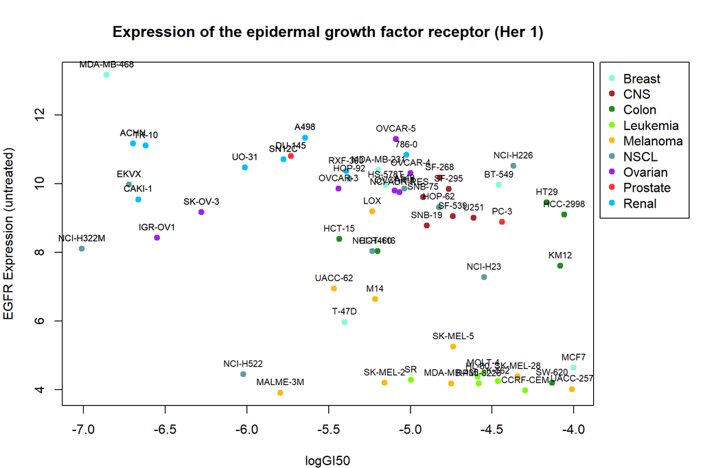

```r
par(mar = c(4, 4, 4, 7), xpd = "TRUE")
plot(LogGI50_59_celllines, e_untreated ["EGFR",],
      col = e_color_cancertype,
      pch = 19,
     xlab = "logGI50",
     ylab = "EGFR Expression (untreated)",
     main = "Expression of the epidermal growth factor receptor (Her 1)",
     cex.main = 1.2)
legend("topright",
    legend = names(color_palette_cancertype),
    col = color_palette_cancertype,
    pch = 19,
    inset = c(-0.18, 0),
    xpd = TRUE)

text(LogGI50_59_celllines, e_untreated ["EGFR",],
     labels  = names(LogGI50_59_celllines),
     cex = 0.7,
     pos = 3)

labeled_celllines_EGFR <- names(LogGI50_59_celllines)[LogGI50_59_celllines < - 5.5
                                                        & e_untreated ["EGFR", ] > 8]

text(LogGI50_59_celllines[labeled_celllines_EGFR], e_untreated ["EGFR", labeled_celllines_EGFR],
     labels = labeled_celllines_EGFR,
     cex = 0.7,
     pos = 3)
#Funktioniert noch nicht
abline(lm(LogGI50_59_celllines ~ e_untreated["EGFR",]))
```

### lineare regression Her 1 expression against the GI50 values

```r
linearMod_Her1 <- lm(LogGI50_59_celllines ~ e_untreated ["EGFR",])  # build linear regression model on full data
summary(linearMod_Her1)
```

```
Call:
lm(formula = LogGI50_59_celllines ~ e_untreated["EGFR", ])

Residuals:
     Min       1Q   Median       3Q      Max
-1.85461 -0.30720  0.09961  0.47793  1.22004

Coefficients:
                      Estimate Std. Error t value Pr(>|t|)
(Intercept)           -4.14018    0.31366 -13.199  < 2e-16 ***
e_untreated["EGFR", ] -0.12518    0.03657  -3.423  0.00115 **
---
Signif. codes:  0 '***' 0.001 '**' 0.01 '*' 0.05 '.' 0.1 ' ' 1

Residual standard error: 0.7174 on 57 degrees of freedom
Multiple R-squared:  0.1705,    Adjusted R-squared:  0.156
F-statistic: 11.72 on 1 and 57 DF,  p-value: 0.001152
```

mode does not fit that well, only 17% can be disrecped by Her1 expression. Maybe we have to consider all types of Her receptors 1-4!!! cause the composition of Her1 and Her3/4 play a part when it comes to bad/good prognoses an therfore could play a role in the GI50 values an the success of erlotinib treatment.

## 4. Milestone: Which pathways are affected?

The aim of our last milestone was to identify the pathways which are most regulated due to erlotinib. We used two methods to create a heatmap of the pathways. In the first one Supplementary Table S2 from the NCI TPW was used. In this table 5-15 genes are listed for each of the pathways. The second method was to use the R package progeny, which scores 100 genes per pathway to calculate the pathway activity and should explain better the pathway activity since more data is regarded.

### 1. Pathways according Supplementary Table S2

First the genes listed for each pathway were stored in one vector. These pathway vectors were than combined in one table called pathways.

```r
#assign genes to pathways (as in supplementary material)
MAPK <- c("AURKA", "AURKB", "SON", "CENPA", "KIF11", "DUSP6", "TPX2", "EGR1")
AKT_PI3K <- c("CFLAR", "XIAP", "BIRC5", "BIRC3", "GADD45A", "MCL1", "BCL2",
              "BCL2L1", "HIF1A", "AR", "STAT3", "IL6", "JUN", "FOS")
  #AP1 for AKT_PI3K excluded (genename does not exist in FC)
  #do they mean with AP1 these 5 genes? AP1AR, AP1B1, AP1G1, AP1G2, AP1M2, AP1S1, AP1S2
  #same problem for VEGF --> VEGFA, VEGFB, VEGFB
Cell_Cycle_Checkpoint <- c("CHEK1", "CHEK2", "TP53", "MDM2", "CDKN1A", "CCNE1", "CDK2",
                           "CDC25A", "SMC1A", "CCNB1", "CDK1", "CDC25B", "CDC25C",
                           "PLK1", "WEE1", "CCND1")
JAK_STAT <- c("SOCS1", "NMI", "BCL2L1", "CDKN1A", "MYC")
Immunity_Related <- c("BCL2L1", "XIAP", "BIRC5", "CFLAR", "IL6", "IL1B", "TNF")
  #PTGS does not exist
DNA_repair <- c("XRCC6", "PRKDC", "DCLRE1C", "XRCC4", "LIG4", "BRCA1",
                "RAD52", "BRCA2", "RAD54L", "ATM", "ATR", "PARP1")
  #NHEJ1 does not exist
DNA_damage <- c("TP53", "FAS", "BAX", "PMAIP1")
  #BBC3 & ARG do not exist
ER_Stress_Survival <- c("HSPA5", "HSP90B1", "XBP1", "P4HB", "ATF4", "GADD45A")
ER_Stress_Apoptotic_Response <- c("ATF3", "DDIT3", "TNFRSF10B", "TRIB3", "BCL2L11", "CASP2")
  #BBC3 & GADD34 do not exist
Apoptosis_extrinsic_activation <- c("BID", "FAS", "CASP8", "CASP9", "APAF1")
Apoptosis_intrinsic_activation <- c("BAX", "BAK1", "BID", "PMAIP1",
                                    "CASP6", "CASP9", "APAF1")
  #BBC3 does not exist
Autophagy_recycling_starvation <- c("MAP1LC3B", "ULK1", "ATG13", "BECN1",
                                    "SQSTM1", "ATG5", "ATG12", "CTSB")
Autophagy_toxic <- c("SQSTM1", "ATG7", "RIPK1", "CTSB")

#create named list of all pathways
pathways <- list(MAPK = MAPK,
                 AKT_PI3K = AKT_PI3K,
                 Cell_Cycle_Checkpoint = Cell_Cycle_Checkpoint,
                 JAK_STAT = JAK_STAT,
                 Immunity_Related = Immunity_Related,
                 DNA_repair = DNA_repair,
                 DNA_damage = DNA_damage,
                 ER_Stress_Survival = ER_Stress_Survival,
                 ER_Stress_Apoptotic_Response = ER_Stress_Apoptotic_Response,
                 Apoptosis_extrinsic_activation = Apoptosis_extrinsic_activation,
                 Apoptosis_intrinsic_activation = Apoptosis_intrinsic_activation,
                 Autophagy_recycling_starvation = Autophagy_recycling_starvation,
                 Autophagy_toxic = Autophagy_toxic)
rm(MAPK, AKT_PI3K, Cell_Cycle_Checkpoint, JAK_STAT, Immunity_Related, DNA_repair,
   DNA_damage, ER_Stress_Survival, ER_Stress_Apoptotic_Response,
   Apoptosis_extrinsic_activation, Apoptosis_intrinsic_activation,
   Autophagy_recycling_starvation, Autophagy_toxic)
```

This pathway table was then used to create the heatmap_data table, in which the mean expression over all genes assigned to a pathway is calculated for each cellline.

```r
#calculate mean FC over genes of one pathway for each sample
heatmap_data <- sapply(1:length(pathways), function(x){ #for each pathway
  sapply(1:ncol(e_foldchange), function(y){ #for each sample
    #calculate mean FC of genes of one pathway
    mean(e_foldchange[pathways[[x]], y])
  })
})

colnames(heatmap_data) <- c(names(pathways))
rownames(heatmap_data) <- colnames(e_foldchange)
```

Proof how many clusters are needed with an elbow plot

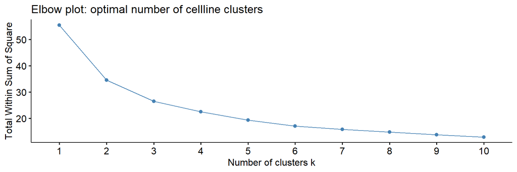

```r
#Elbow plot
library(factoextra)
fviz_nbclust(heatmap_data,
             FUN = hcut,
             method = "wss") + #within cluster sums of squares
  labs(title = "Elbow plot: optimal number of cellline clusters")
```

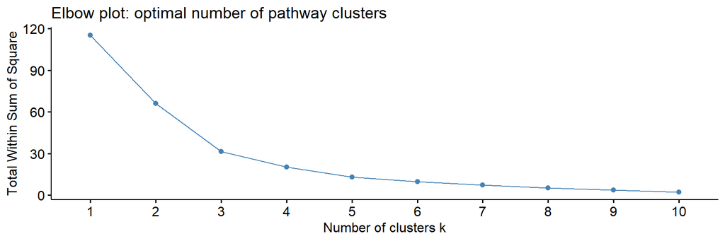

```r
fviz_nbclust(t(heatmap_data),
             FUN = hcut,
             method = "wss") +
  labs(title = "Elbow plot: optimal number of pathway clusters")
```

Colored annotation bars above the heatmap should depict several clusters. Therefore, the dendrogramm was used to first cluster the celllines and afterwards the pathways. 1. Clustering according to cellline:

```r
#Clustering with package dendextend
library(dendextend)
#hierachical clustering (hclust) of celllines
#dist(): euclidean distance
#agglomeration method: "ward.D2"
cellline_clustering <- hclust(dist(heatmap_data), method = "ward.D2")
#cutree: cuts the tree to generate k clusters
cellline_groups <- cutree(tree = as.dendrogram(cellline_clustering), k = 3)

#Create data frame with cancertype for each cellline treated with erlotinib
cellline_cancertype <- as.data.frame(sapply(names(cellline_groups), function(x){
  unname(cellline_annotation[which(cellline_annotation$Cell_Line_Name == x), 2])
}))

#save clustering according to dendrogramm and cancertype
#in a new data frame called cellline_clusters
cellline_clusters <- as.data.frame(cbind(cellline_groups, cellline_cancertype))
colnames(cellline_clusters) <- c("Cellline cluster", "Cancertype cluster")
```

2. Clustering according to pathways:

```r
#cluster pathways:
pathway_clustering <- hclust(dist(t(heatmap_data)), method = "ward.D2")
pathway_groups <- as.data.frame(cutree(tree = as.dendrogram(pathway_clustering), k = 3))
colnames(pathway_groups) <- "Pathway cluster"
```

Create a heatmap with the package pheatmap (pretty heatmap):

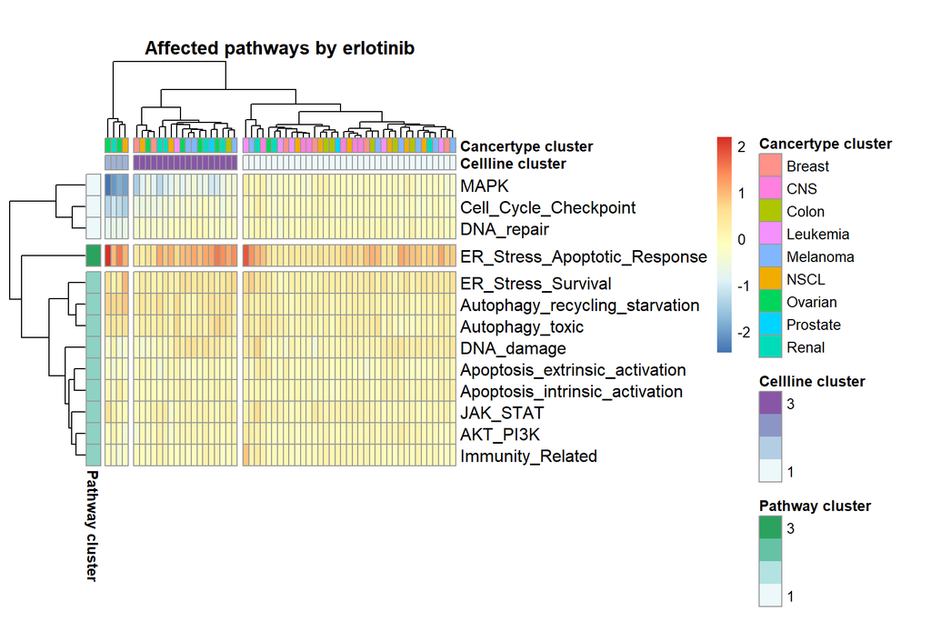

```r
library(pheatmap)
#generate heatmap with colored bars according to clusters
pheatmap(t(heatmap_data),
         clustering_method = "ward.D2",
         annotation_col = cellline_clusters,
         annotation_row = pathway_groups,
         cutree_rows = 3, #makes white spaces between clusters
         cutree_cols = 3,
         main = "Affected pathways by erlotinib",
         mainsize = 1.2,
         show_colnames = FALSE,
         cellwidth = 4,
         cellheight = 15,
         fontsize = 10,
         fontsize_row = 12)
```

### 2. Heatmap with PROGENy

Using PROGENY, which scores the 100 most important genes for each pathway to depict its activity.

```r
library(progeny)
progeny_heatmap <- progeny(e_foldchange)
```

Proof how many clusters are needed with an elbow plot

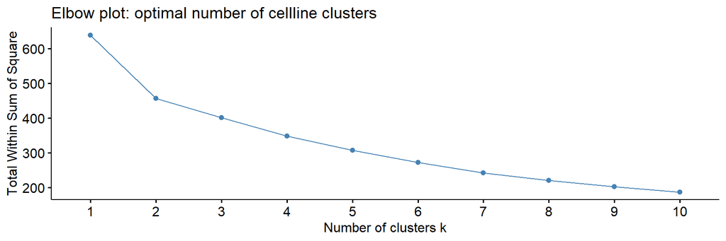

```r
#Elbow plot
library(factoextra)
fviz_nbclust(progeny_heatmap,
             FUN = hcut,
             method = "wss") + #within cluster sums of squares
  labs(title = "Elbow plot: optimal number of cellline clusters")
```

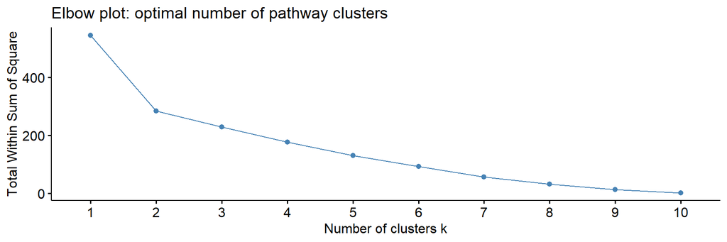

```r
fviz_nbclust(t(progeny_heatmap),
             FUN = hcut,
             method = "wss") +
  labs(title = "Elbow plot: optimal number of pathway clusters")
```

Clustering according to cellline and pathway

```r
#cluster celllines:
cellline_clustering <- hclust(dist(progeny_heatmap), method = "ward.D2")
cellline_groups <- as.data.frame(cutree(tree = as.dendrogram(cellline_clustering), k = 2))
cellline_clusters <- as.data.frame(cbind(cellline_groups, cellline_cancertype))
colnames(cellline_clusters) <- c("Cellline cluster", "Cancertype cluster")
#cluster pathways:
pathway_clustering <- hclust(dist(t(progeny_heatmap)), method = "ward.D2")
pathway_groups <- as.data.frame(cutree(tree = as.dendrogram(pathway_clustering), k = 2))
colnames(pathway_groups) <- "Pathway cluster"
```

Create heatmap

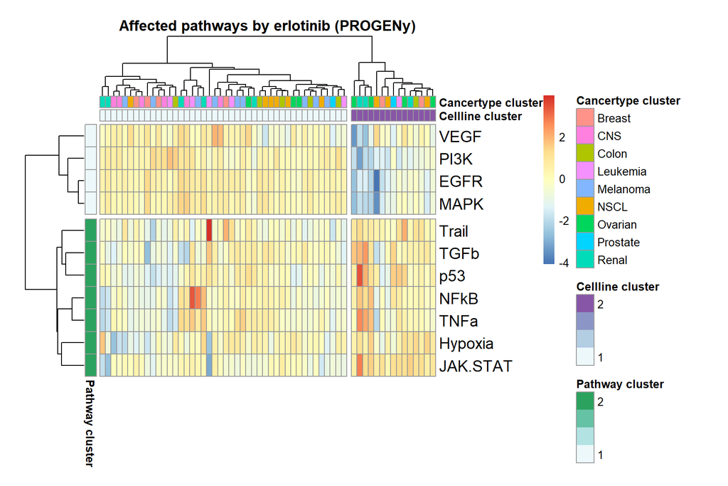

```r
par(mar = c(8, 2, 2, 2))
pheatmap(t(progeny_heatmap),
         clustering_method = "ward.D2",
         annotation_col = cellline_clusters,
         annotation_row = pathway_groups,
         cutree_rows = 2,
         cutree_cols = 2,
         main = "Affected pathways by erlotinib (PROGENy)",
         mainsize = 1.2,
         show_colnames = FALSE,
         cellwidth = 5,
         cellheight = 20,
         fontsize = 10,
         fontsize_row = 14)
```